# Data Visualization for Political Social Work

Andy Grogan-Kaylor

2022-01-03

# How to Navigate This Presentation

> As you move forward through this presentation you can press `b` to make text bigger, or `s` to make text smaller.

# Outline of Conversation

# Our Discussion Today

- Purpose: Focus on the *conceptual language* of data viz.
- **Not** a deep dive into the technical tools for doing dataviz.
- Whatever tool you are using (Paper and Pencil, Markers on Whiteboard, Excel, Google Sheets, R), what are some conceptual considerations in making a data visualization?
- Considerations for being part of a *team* conversation about visualizing data.
- More specific technical resources at end.

# Our Data

# Basic Considerations

# The Nature of Your Variables Determines the Nature of Your DataViz

- Deciding upon the right data visualization to represent your data can be a daunting process.
- I believe that a *starting point* for this thinking is some basic statistical thinking about the *type* of variables that you have.
- At the broadest level, variables may be conceptualized as *categorical* variables, or *continuous* variables.

# Variable Types

- *categorical variables* represent unordered categories like *neighborhood*, or *religious affiliation*, or *place of residence*.
- *continuous variables* represent a continuous scale like a *mental health scale*, or a *measure of life expectancy*.

# Visualization Possibilities

[How To Choose A Chart](https://agrogan1.github.io/dataviz/how-to-choose-a-chart/how-to-choose-a-chart-a-visual-guide.pdf)

[figure not shown]

# Story-Telling

# Your Graph Should Be A Self-Contained Story

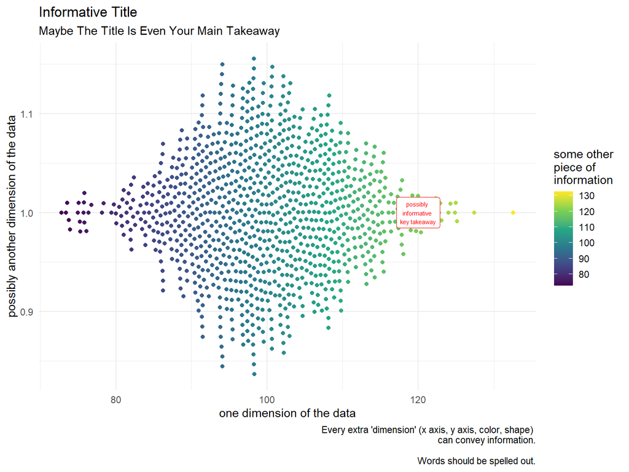

# Your Graph Should Be Embedded In A Story

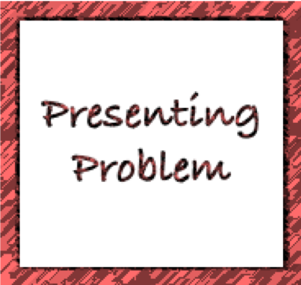

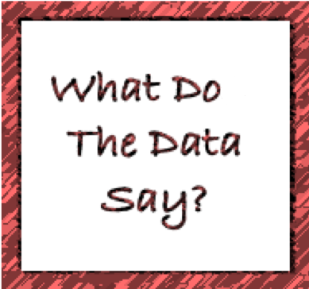

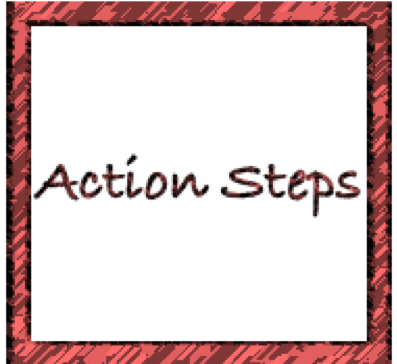

# Color

# Greyscale Graph

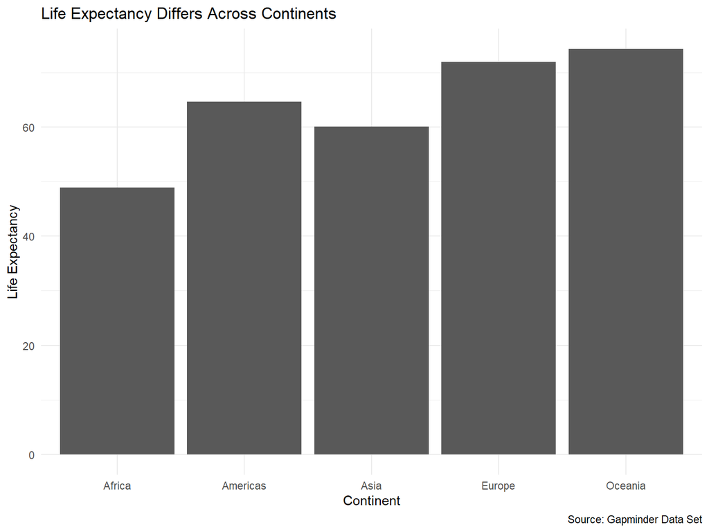

# Color is Organizational Identity

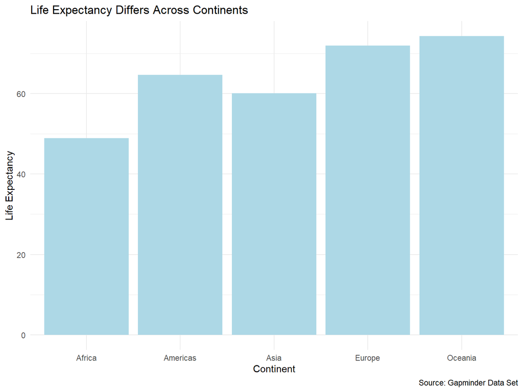

# Color Is Information

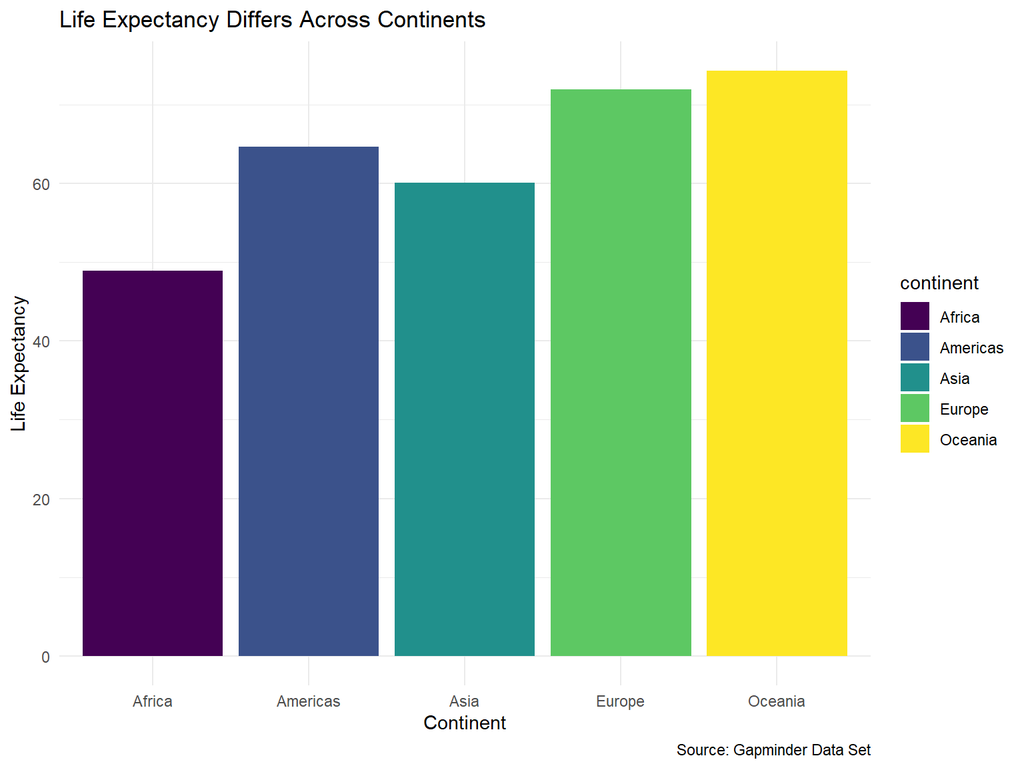

# Color Is Accessibility

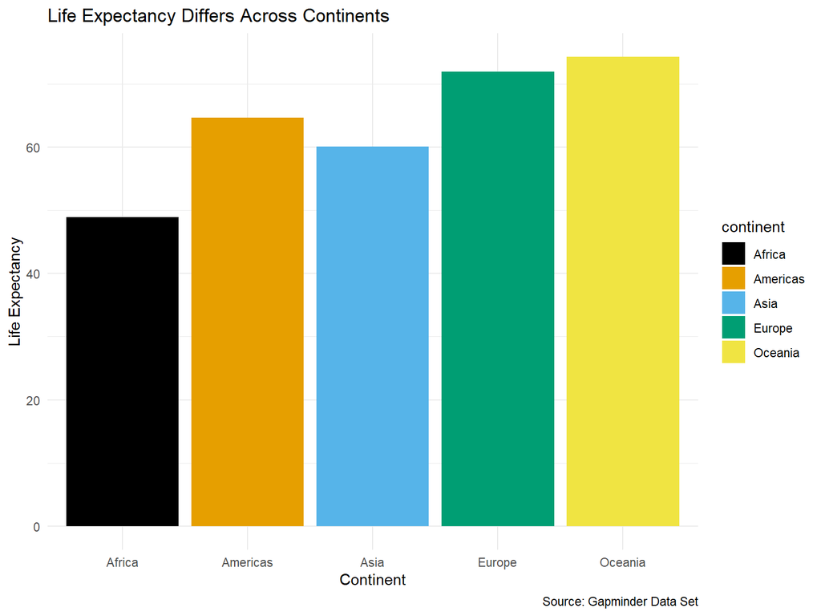

# Color Is Emphasis

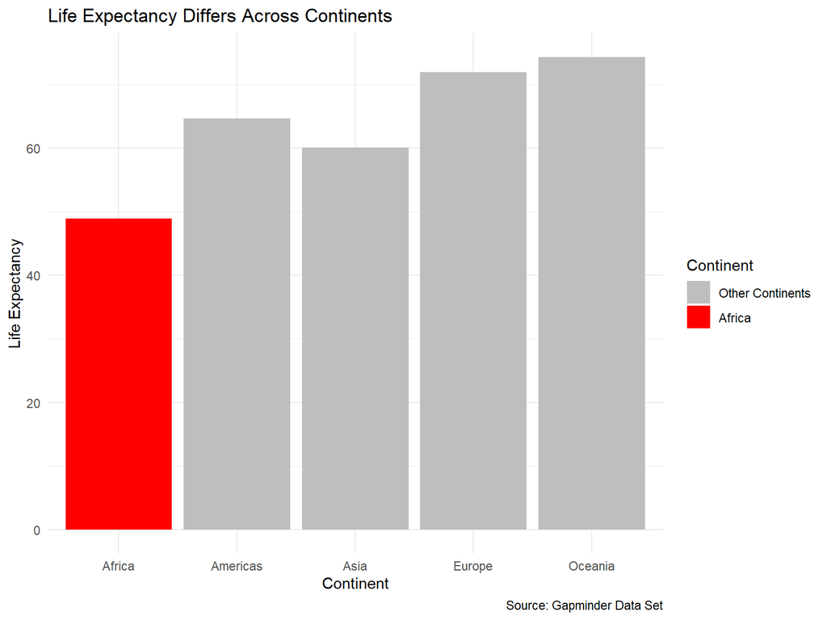

# Cognition

# “Graphical Perception”

“Ordering elementary tasks by accuracy (Cleveland and McGill 1985):”

1. Position along a common scale
2. Position on identical but nonaligned scales
3. Length
4. Angle & Slope
5. Area
6. Volume, Density, Color Saturation
7. Color Hue

# Example (Position Along A Common Scale)

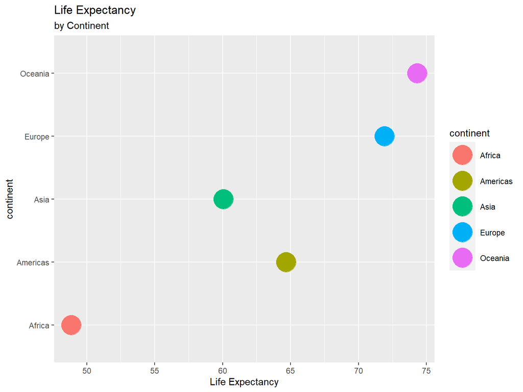

# Example (Length)

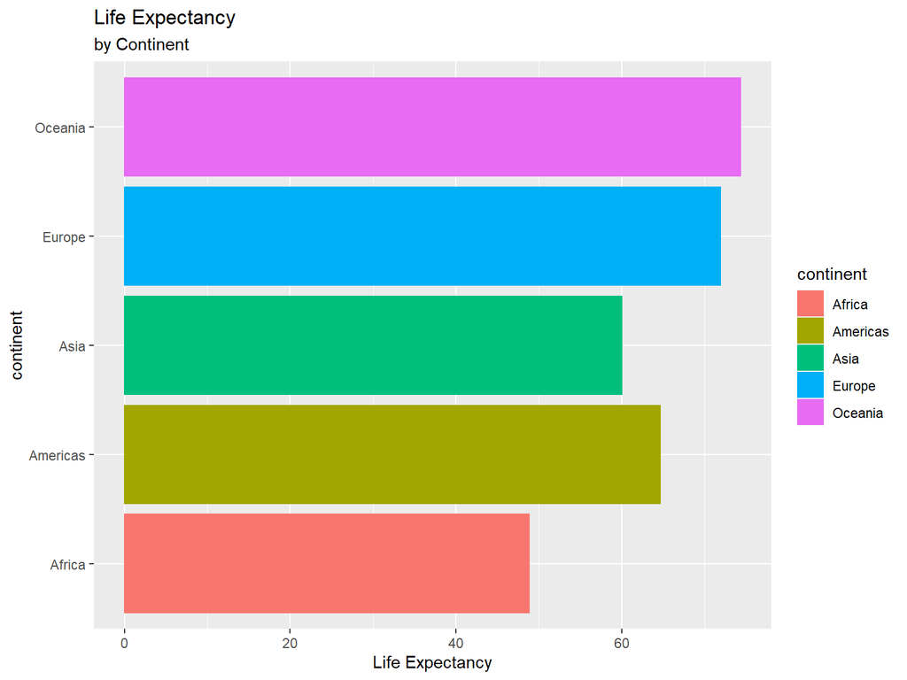

# Example (Angle)

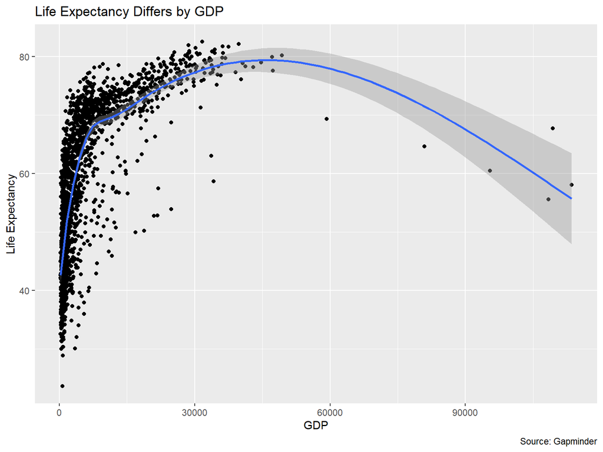

# Resources for Further Learning

# Resources

- [How to Choose a Chart: A Visual Guide](https://agrogan1.github.io/dataviz/how-to-choose-a-chart/how-to-choose-a-chart-a-visual-guide.pdf). [[Extended Version](https://agrogan1.github.io/dataviz/how-to-choose-a-chart/how-to-choose-a-chart-v3.html)]
- *Introduction to R*:
  - [HTML Web Book](https://agrogan1.github.io/R/introduction-to-R/introduction-to-R.html)
- *Introduction to ggplot2*:
  - [HTML Web Book](https://agrogan1.github.io/R/introduction-to-ggplot2/introduction-to-ggplot2.html)
- *Two Page R*:
  - [PDF](https://agrogan1.github.io/R/two-page-R/two-page-R.pdf)
- *Two Page ggplot2*:
  - [PDF](https://agrogan1.github.io/R/two-page-ggplot2/two-page-ggplot2.pdf)

# Questions?

# Please Contact

agrogan@umich.edu

https://agrogan1.github.io/

# References

Cleveland, William S, and Robert McGill. 1985. “Graphical Perception and Graphical Methods for Analyzing Scientific Data.” *Science* 229 (4716): 828–33. http://www.jstor.org/stable/1695272.